# HE Assignment 5 – Regression

Shawn Abdian, Lexie Brown, Jenna Swiecki, Carolina Trevino, Saeeda Zaman,Bryan Yang

07/12/22

# Overview

In this assignment you will practice using the regression algorithm to create a model for explaining the interest rate for home loans that were granted in the state of Illinois.

### Requirements

1. (1 point) Create a new RMD file in RStudio and use a code chunk to complete the following tasks: Load the following libraries: tidyverse, magrittr, lubridate, and corrplot packages. (You may need to install those libraries if you have not already done so.)

```r
library(tidyverse)
library(lubridate)
library(jtools)
library(ggstance)
library(huxtable)
```

```r
library(corrplot)
```

- Read in the hmdaInterestRate.rds file.

```r
df1 <- read_rds('hmdaInterestRate.rds')
```

- Report the structure of the dataframe. (No need to comment on the structure.)

```r
str(df1)
```

```
## 'data.frame':    6509 obs. of  14 variables:
##  $ activity_year            : Factor w/ 2 levels "2019","2018": 2 2 2 2 2 2 2 2 2 2 ...
##  $ state_code               : Factor w/ 1 level "IL": 1 1 1 1 1 1 1 1 1 1 ...
##  $ county_code              : Factor w/ 3 levels "Missing","Coles",..: 1 1 1 1 2 1 1 1 1 1 ...
##  $ aus_1                    : Factor w/ 6 levels "Desktop Underwriter (DU)",..: 2 1 3 4 1 4 1 1 1 1 ...
##  $ loan_purpose             : Factor w/ 6 levels "Home purchase",..: 2 3 1 1 3 3 1 1 1 1 ...
##  $ applicant_ethnicity_1    : Factor w/ 8 levels "Not Hispanic or Latino",..: 2 1 1 1 2 1 1 1 1 1 ...
##  $ applicant_sex            : Factor w/ 4 levels "Male","Female",..: 1 2 1 1 3 1 1 1 2 1 ...
##  $ derived_loan_product_type: Factor w/ 6 levels "Conventional:First Lien",..: 1 1 1 2 4 2 1 1 1 1 ...
##  $ interest_rate            : num  3.62 4.99 4.12 4.25 3.99 ...
##  $ loan_amount              : num  185000 105000 255000 255000 95000 205000 235000 105000 275000 75000 ...
##  $ loan_term                : num  180 360 360 360 240 360 360 360 360 360 ...
##  $ property_value           : num  235000 215000 265000 255000 105000 265000 335000 265000 285000 85000 ...
##  $ income                   : num  154000 88000 66000 89000 81000 61000 84000 76000 160000 35000 ...
##  $ applicant_age            : num  50 50 30 50 60 40 30 50 30 30 ...
```

2. (1 point) Data preparation: Replace the values in the following columns with the same value divided by 1,000: loan_amount, property_value, and income. (This will make it easier to see the impact on the interest rate.)

```r
df1$loan_amount <- df1$loan_amount / 1000
df1$property_value <- df1$property_value / 1000
df1$income <- df1$income/ 1000
```

- Create a new column, ltp, that is equal to the values in the loan_amount column divided by the values in the property_value column.

```r
df1$ltp = df1$loan_amount / df1$property_value
```

- Filter the data to keep observations for which income is less than 300 (i.e., $300,000).

```r
df2 <- df1 %>% filter(income < 300)
```

- Report a summary of all columns. (No need to comment on the summary of the columns.)

```r
summary(df2)
```

```
##  activity_year state_code     county_code
##  2019:3151     IL:6267    Missing   :5389
##  2018:3116                Coles     : 733
##                           Cumberland: 145
##
##
##
##
##                                                    aus_1
##  Desktop Underwriter (DU)                             :3091
##  Not applicable                                       : 941
##  Loan Propspector (LP) or Loan Product Advisor        :1548
##  Technology Open to Approved Lenders (TOTAL) Scorecard: 470
##  Guaranteed Underwriting System                       : 158
##  Other                                                :  59
##
##                loan_purpose                            applicant_ethnicity_1
##  Home purchase       :3945   Not Hispanic or Latino               :5558
##  Refinancing         :1002   Information not provided by applicant: 475
##  Cash-out refinancing: 824   Hispanic or Latino                   : 204
##  Other purpose       : 247   Other Hispanic or Latino             :  14
##  Home improvement    : 248   Mexican                              :  11
##  Not applicable      :   1   Not applicable                       :   2
##                              (Other)                              :   3
##                                  applicant_sex
##  Male                                   :3869
##  Female                                 :2063
##  information not provided by applicant  : 332
##  Applicant selected both male and female:   3
##
##
##
##                  derived_loan_product_type interest_rate    loan_amount
##  Conventional:First Lien      :4678        Min.   :2.400   Min.   :  5.0
##  FHA:First Lien               : 605        1st Qu.:3.990   1st Qu.: 85.0
##  Conventional:Subordinate Lien: 485        Median :4.500   Median :125.0
##  VA:First Lien                : 319        Mean   :4.516   Mean   :143.3
##  FSA/RHS:First Lien           : 179        3rd Qu.:4.990   3rd Qu.:185.0
##  FHA:Subordinate Lien         :   1        Max.   :6.980   Max.   :785.0
##
##    loan_term     property_value      income       applicant_age
##  Min.   :  6.0   Min.   : 15.0   Min.   :  1.00   Min.   :30.00
##  1st Qu.:240.0   1st Qu.:115.0   1st Qu.: 51.00   1st Qu.:30.00
##  Median :360.0   Median :165.0   Median : 77.00   Median :40.00
##  Mean   :307.2   Mean   :193.2   Mean   : 89.31   Mean   :45.53
##  3rd Qu.:360.0   3rd Qu.:245.0   3rd Qu.:114.00   3rd Qu.:60.00
##  Max.   :480.0   Max.   :925.0   Max.   :299.00   Max.   :70.00
##
##       ltp
##  Min.   :0.01408
##  1st Qu.:0.69697
##  Median :0.80822
##  Mean   :0.76296
##  3rd Qu.:0.93103
##  Max.   :1.26667
##
```

3. (1 point) Create a correlation plot of the following columns: interest_rate, ltp, income, applicant_age, property_value, and loan_amount.

```r
cdf2 <- cor(df2 %>% select(interest_rate, ltp, income, applicant_age, property_value, loan_amount))
cdf2
```

```
##                interest_rate        ltp      income applicant_age
## interest_rate     1.00000000 -0.3188587 -0.04683836   0.109516616
## ltp              -0.31885873  1.0000000 -0.13544451  -0.339076509
## income           -0.04683836 -0.1354445  1.00000000   0.045085985
## applicant_age     0.10951662 -0.3390765  0.04508598   1.000000000
## property_value   -0.16659083 -0.1658255  0.58661218   0.003786898
## loan_amount      -0.33150222  0.3903140  0.46424427  -0.168519166
##                property_value loan_amount
## interest_rate    -0.166590831  -0.3315022
## ltp              -0.165825527   0.3903140
## income            0.586612176   0.4642443
## applicant_age     0.003786898  -0.1685192
## property_value    1.000000000   0.8000781
## loan_amount       0.800078124   1.0000000
```

- Below the plot, identify what variable has the strongest negative correlation with interest_rate. Comment on what might explain why that correlation is negative.

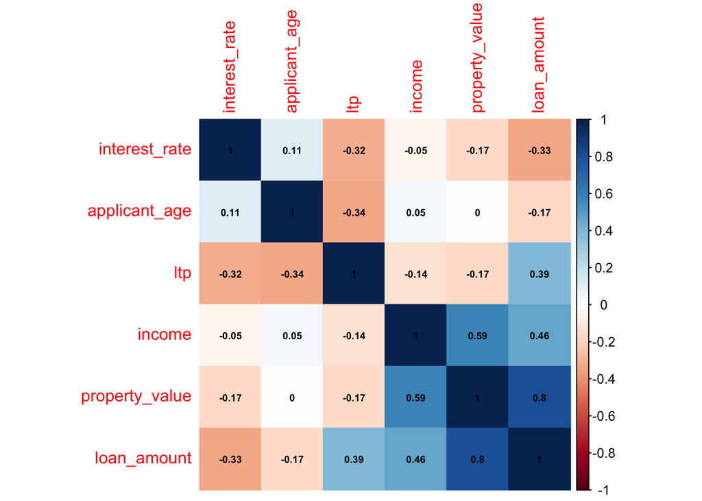

```r
corrplot(cdf2
         , method = 'color' #pie and ellipse
         , order = 'hclust' #orders the variables so that ones that behave similarly are placed next to each other
         , addCoef.col = 'black'
         , number.cex = .6  #lower values decrease the size of the numbers in the cells
         )
```

**Interest rate and loan amount have the strongest negative correlation with each other. We can also see the similar correlation with loan to property value with interest rate signaling cheaper properties have higher loan to property ratios than pricier properties. In contrast we can see higher income is positively correlated with property value and loan amount. Typically, larger down payment lowers the interest rate for the loan. These correlations explain high income earners, who are buying more expensive properties, are likely to pay more down payments to get the most optimal interest rates possible than lower income earners who don’t have this option hence strong negative correlation between interest rate and loan amount.**

4. (1 point) Regress interest_rate on ltp. Interpret the coefficient estimate on ltp.

```r
lm1 <- lm(interest_rate ~ ltp, data = df2)
summary(lm1)
```

```
##
## Call:
## lm(formula = interest_rate ~ ltp, data = df2)
##
## Residuals:
##     Min      1Q  Median      3Q     Max
## -2.8933 -0.5055  0.0285  0.4834  2.5221
##
## Coefficients:
##             Estimate Std. Error t value Pr(>|t|)
## (Intercept)  5.31852    0.03147  168.98   <2e-16 ***
## ltp         -1.05188    0.03950  -26.63   <2e-16 ***
## ---
## Signif. codes:  0 '***' 0.001 '**' 0.01 '*' 0.05 '.' 0.1 ' ' 1
##
## Residual standard error: 0.7182 on 6265 degrees of freedom
## Multiple R-squared:  0.1017, Adjusted R-squared:  0.1015
## F-statistic: 709.1 on 1 and 6265 DF,  p-value: < 2.2e-16
```

**Regressing interest rate on loan to property value (ltp), the coefficient estimates are 5.319 and -1.052 respectively with statistical significance. Using these parameters from regression, we can have the following linear model:$\textrm{interest_rate} = -1.052*\textrm{ltp} + 5.319$.**

**The R squared is 0.102 or 10% of interest rate can be explained by ltp.**

5. (3 points) Regress interest_rate on ltp and loan_amount. Comment on the change in the adjusted R-squared, as well as the change in the coefficient on ltp.

```r
lm2 <- lm(interest_rate ~ ltp + loan_amount, data = df2)
summary(lm2)
```

```
##
## Call:
## lm(formula = interest_rate ~ ltp + loan_amount, data = df2)
##
## Residuals:
##      Min       1Q   Median       3Q      Max
## -2.93510 -0.47999  0.03926  0.46210  2.29461
##
## Coefficients:
##               Estimate Std. Error t value Pr(>|t|)
## (Intercept)  5.3848432  0.0307701  175.00   <2e-16 ***
## ltp         -0.7373702  0.0416838  -17.69   <2e-16 ***
## loan_amount -0.0021367  0.0001105  -19.33   <2e-16 ***
## ---
## Signif. codes:  0 '***' 0.001 '**' 0.01 '*' 0.05 '.' 0.1 ' ' 1
##
## Residual standard error: 0.6978 on 6264 degrees of freedom
## Multiple R-squared:  0.1522, Adjusted R-squared:  0.152
## F-statistic: 562.5 on 2 and 6264 DF,  p-value: < 2.2e-16
```

**Regressing interest rate on loan to property value (ltp) and loan amount, the coefficient estimates are 5.385, -0.737, and -0.002 respectively with statistical significance on all three coefficients. Using these parameters from regression, we can have the following linear model: $\textrm{interest_rate} = -0.737*\textrm{ltp} -0.002*\textrm{loan_amount} + 5.385$.**

**The Adjusted R squared of this multiple regression is 0.152 compared to 0.102 from the previous simple regression’s R squared. This means 15% of interest rate can be explained by combination of ltp and loan amount.**

6. (3 points) Regress interest_rate on ltp, loan_amount, and aus_1. Interpret the change in adjusted R-squared, as well as the coefficients for each independent variable.

```r
lm3 <- lm(interest_rate ~ ltp + loan_amount + aus_1, data = df2)
summary(lm3)
```

```
##
## Call:
## lm(formula = interest_rate ~ ltp + loan_amount + aus_1, data = df2)
##
## Residuals:
##      Min       1Q   Median       3Q      Max
## -3.06937 -0.44178  0.04104  0.44611  2.33427
##
## Coefficients:
##                                                             Estimate Std. Error
## (Intercept)                                                 4.589412   0.039711
## ltp                                                         0.025007   0.048639
## loan_amount                                                -0.001714   0.000106
## aus_1Not applicable                                         0.905072   0.030109
## aus_1Loan Propspector (LP) or Loan Product Advisor          0.007257   0.020211
## aus_1Technology Open to Approved Lenders (TOTAL) Scorecard  0.166965   0.032965
## aus_1Guaranteed Underwriting System                        -0.032727   0.054296
## aus_1Other                                                  0.403022   0.085503
##                                                            t value Pr(>|t|)
## (Intercept)                                                115.571  < 2e-16 ***
## ltp                                                          0.514    0.607
## loan_amount                                                -16.174  < 2e-16 ***
## aus_1Not applicable                                         30.060  < 2e-16 ***
## aus_1Loan Propspector (LP) or Loan Product Advisor           0.359    0.720
## aus_1Technology Open to Approved Lenders (TOTAL) Scorecard   5.065 4.20e-07 ***
## aus_1Guaranteed Underwriting System                         -0.603    0.547
## aus_1Other                                                   4.714 2.49e-06 ***
## ---
## Signif. codes:  0 '***' 0.001 '**' 0.01 '*' 0.05 '.' 0.1 ' ' 1
##
## Residual standard error: 0.6489 on 6259 degrees of freedom
## Multiple R-squared:  0.2675, Adjusted R-squared:  0.2667
## F-statistic: 326.6 on 7 and 6259 DF,  p-value: < 2.2e-16
```

**The Adjusted R squared of this multiple regression is 0.2667 compared to 0.152 from the previous multiple regression’s adjusted R squared. This means 27% of interest rate can be explained by combination of the independent variables from the model.**